# More nimble programming features and techniques

TWS 2024 Workshop

NIMBLE Development Team

October 2024

# Agenda

In this module we will cover:

- Calling R functions from (compiled) nimbleFunctions.
- Writing nimbleFunctions that use `setup` code and use models.
  - Example: maximum likelihood (without random effects / latent states)
- Using the Automatic Differentiation system to get derivatives.
- Holding large data objects outside of models.
- Writing MCMC samplers and using them within nimble’s MCMC system.

# Calling R functions from (compiled) nimbleFunctions.

- R is a slow, interpreted (i.e. not compiled) language.
- There is no general R compiler and it would be extremely difficult to make one. For example, code itself is an object in the language.
- That’s why the nimble compiler handles only a small subset of R syntax, mostly math and basic flow control.
- Sometimes, you really want to call something in R from model code that you could not easily code directly in a nimbleFunction. Example: least-cost path distance.
- Use `nimbleRcall` for this. There will be computational overhead, but you can get what you want.

# Example of `nimbleRcall`

Let’s say we are calculating Gaussian decay with distance from a latent location to a set of fixed locations. For example, in spatial capture-recapture there is a latent location for each animal’s activity center and the fixed locations are for detectors such as camera traps.

Here is a basic version of a model with only this calculation. (Notice we can make a model object even without stochastic nodes or data nodes. We will just use it as a calculator.)

```r
dd_code1 <- nimbleCode({
  # s[1:2] will be the latent location
  # rho will be a decay parameter
  for(i in 1:num_det) {
    d2[i] <- (s[1] - x[i,1])^2 + (s[2] - x[i,2])^2
    w[i] <- exp(-d2[i] / rho)
  }
})
```

Set up a set of random locations.

```r
set.seed(1)
num_det <- 5
x <- matrix(runif(10, -100, 100), ncol=2)
s <- c(25, 75)
rho <- 2500
```

```r
dd_model1 <- nimbleModel(dd_code1,
                         constants=list(num_det = num_det, x = x))
```

```
## Defining model
```

```
## Building model
```

```
## Running calculate on model
##   [Note] Any error reports that follow may simply reflect missing values in model variables.
```

```
## Checking model sizes and dimensions
```

```
##   [Note] This model is not fully initialized. This is not an error.
##          To see which variables are not initialized, use model$initializeInfo().
##          For more information on model initialization, see help(modelInitialization).
```

```r
values(dd_model1, c("s[1:2]", "rho")) <- c(s, rho)
dd_model1$d2 # Should be NA because these are not calculated yet
```

```
## [1] NA NA NA NA NA
```

```r
dd_model1$calculate("d2")
```

```
## [1] 0
```

```r
dd_model1$d2 # Now they are calculated
```

```
## [1]  5191.244  2752.039  1944.074  5626.662 33620.590
```

```r
dd_model1$w # Not yet calculated
```

```
## [1] NA NA NA NA NA
```

```r
dd_model1$calculate("w")
```

```
## [1] 0
```

```r
dd_model1$w # Nw they are calculated
```

```
## [1] 1.253685e-01 3.325998e-01 4.594939e-01 1.053292e-01 1.443794e-06
```

```r
# we could do the same steps with the compiled model
Cdd_model1 <- compileNimble(dd_model1)
```

```
## Compiling
##   [Note] This may take a minute.
##   [Note] Use 'showCompilerOutput = TRUE' to see C++ compilation details.
```

# Example of `nimbleRcall` (cont)

Let’s say that instead of the simple case here, we really have something so involved that we need to call R to do it.

```r
calc_w <- function(s, x, rho) {
  num_det <- nrow(x)
  d2 <- w <- numeric(num_det)
  for(i in 1:num_det) {
    d2[i] <- (s[1] - x[i,1])^2 + (s[2] - x[i,2])^2
    w[i] <- exp(-d2[i] / rho)
  }
  w
}
# check that it works
calc_w(s, x, rho)
```

```
## [1] 1.253685e-01 3.325998e-01 4.594939e-01 1.053292e-01 1.443794e-06
```

```r
R_calc_w <- nimbleRcall(function(s = double(1), x = double(2), rho = double(0)) {},
                        returnType = double(1),
                        "calc_w"
                        )
dd_code2 <- nimbleCode({
  # s[1:2] will be the latent location
  # rho will be a decay parameter
  w[1:num_det] <- R_calc_w(s[1:2], x[1:num_det, 1:2], rho)
})

dd_model2 <- nimbleModel(dd_code2,
                         constants=list(num_det = num_det, x = x))
```

```
## Defining model
```

```
## Building model
```

```
## Setting data and initial values
```

```
## Running calculate on model
##   [Note] Any error reports that follow may simply reflect missing values in model variables.
```

```
## Checking model sizes and dimensions
```

```
##   [Note] This model is not fully initialized. This is not an error.
##          To see which variables are not initialized, use model$initializeInfo().
##          For more information on model initialization, see help(modelInitialization).
```

```r
values(dd_model2, c("s[1:2]", "rho")) <- c(s, rho)
Cdd_model2 <- compileNimble(dd_model2)
```

```
## Compiling
##   [Note] This may take a minute.
##   [Note] Use 'showCompilerOutput = TRUE' to see C++ compilation details.
```

```r
Cdd_model2$w # Not yet calculated
```

```
## [1] NA NA NA NA NA
```

```r
Cdd_model2$calculate("w")
```

```
## [1] 0
```

```r
Cdd_model2$w # Nw they are calculated
```

```
## [1] 1.253685e-01 3.325998e-01 4.594939e-01 1.053292e-01 1.443794e-06
```

```r
# try this
# debug(calc_w)
# Cdd_model2$calculate("w")
# then use "n" for the next line or "c" to continue without stopping again.
# Inspect variables at any time.
```

# Example of `nimbleRcall` (cont)

### Side note: We could have vectorized this calculation in the model code:

```r
dd_code3 <- nimbleCode({
  # s[1:2] will be the latent location
  # rho will be a decay parameter
  w[1:num_det] <- exp( - ((s[1] - x[1:num_det,1])^2 +
                          (s[2] - x[1:num_det,2])^2  )/rho)
})
dd_model3 <- nimbleModel(dd_code3,
                         constants=list(num_det = num_det, x = x))
```

```
## Defining model
```

```
## Building model
```

```
## Setting data and initial values
```

```
## Running calculate on model
##   [Note] Any error reports that follow may simply reflect missing values in model variables.
```

```
## Checking model sizes and dimensions
```

```
##   [Note] This model is not fully initialized. This is not an error.
##          To see which variables are not initialized, use model$initializeInfo().
##          For more information on model initialization, see help(modelInitialization).
```

```r
values(dd_model3, c("s[1:2]", "rho")) <- c(s, rho)
dd_model3$calculate("w")
```

```
## [1] 0
```

```r
dd_model3$w
```

```
## [1] 1.253685e-01 3.325998e-01 4.594939e-01 1.053292e-01 1.443794e-06
```

# nimbleFunctions that use `setup` code

So far we have seen the simple version of nimbleFunctions. They use a special subset of R-like syntax and are strongly typed (unlike R in general).

When a nimbleFunction contains a `setup` function, it can retain variables between calls. (Internally, it becomes a class definition, not simply a function.)

Here is a toy example (with no model).

```r
foo <- nimbleFunction(
  setup = function(x) {
    my_x <- x # assume x is a vector
  },
  run = function(v = double()) {
    return(v*my_x)
    returnType(double(1))
  }
)
foo1 <- foo(1:5)
foo1$run(2)
```

```
## [1]  2  4  6  8 10
```

```r
foo2 <- foo(101:105)
foo2$run(2)
```

```
## [1] 202 204 206 208 210
```

`my_x` is automatically retained (as a “member variable”) because it appears in `setup` and is used in `run`. (Hence, there is no need to explicitly declare member variables. Just use them.)

Actually, we could have used simply `setup = function(x){}` and then used `x` in `run`.

We can have more functions like `run` called “methods” by providing a `methods` argument.

# nimbleFunctions that use `setup` code (cont)

Let’s compile `foo1` and `foo2`

```r
comp <- compileNimble(foo1, foo2)
```

```
## Compiling
##   [Note] This may take a minute.
##   [Note] Use 'showCompilerOutput = TRUE' to see C++ compilation details.
```

```r
Cfoo1 <- comp$foo1
Cfoo2 <- comp$foo2
foo1$run(2)
```

```
## [1]  2  4  6  8 10
```

```r
foo2$run(2)
```

```
## [1] 202 204 206 208 210
```

# nimbleFunctions that use models.

Now let’s make a nimbleFunction that uses a model. We’ll make a simple log likelihood calculator (assuming no need to integrate over random effects or latent states).

```r
logLik_NF <- nimbleFunction(
  setup = function(model, paramNodes) {
    if(missing(paramNodes)) paramNodes <- model$getNodeNames(topOnly = TRUE)
    calcNodes <- model$getDependencies(paramNodes, self=FALSE)
  },
  methods = list(
    calcLogLik = function(v = double(1)) {
      values(model, paramNodes) <<- v
      ll <- model$calculate(calcNodes)
      return(ll)
      returnType(double())
    }
  )
)
```

# nimbleFunctions that use use models (cont).

Let’s make a toy logistic regression model.

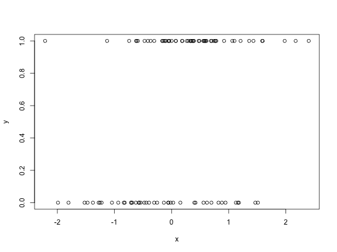

```r
set.seed(1)
x <- rnorm(100)
eta <- 0.2 + 0.5 * x
p <- expit(eta)
y <- rbinom(100, size = 1, prob = p)
plot(x, y)
```

Here is the model fit by `glm`

```r
summary(glm(y ~ x, family = binomial))
```

```
##
## Call:
## glm(formula = y ~ x, family = binomial)
##
## Coefficients:
##             Estimate Std. Error z value Pr(>|z|)
## (Intercept)   0.2229     0.2148   1.038  0.29929
## x             0.8534     0.2696   3.165  0.00155 **
## ---
## Signif. codes:  0 '***' 0.001 '**' 0.01 '*' 0.05 '.' 0.1 ' ' 1
##
## (Dispersion parameter for binomial family taken to be 1)
##
##     Null deviance: 136.66  on 99  degrees of freedom
## Residual deviance: 124.76  on 98  degrees of freedom
## AIC: 128.76
##
## Number of Fisher Scoring iterations: 4
```

# nimbleFunctions that use use models (cont).

Now let’s fit the model by maximizing the log likelihood from our calculator.

```r
m <- nimbleModel(
  nimbleCode({
    intercept ~ dnorm(0, sd = 100) # The priors are not necessary but help with the default paramNodes
    slope ~ dnorm(0, sd = 100)
    for(i in 1:N) {
      y[i] ~ dbern( expit(intercept + slope*x[i])  )
    }
  }),
  data = list(x = x, y = y),
  constants = list(N = 100)
)
```

```
## Defining model
```

```
## Building model
```

```
## Setting data and initial values
```

```
## Running calculate on model
##   [Note] Any error reports that follow may simply reflect missing values in model variables.
```

```
## Checking model sizes and dimensions
```

```
##   [Note] This model is not fully initialized. This is not an error.
##          To see which variables are not initialized, use model$initializeInfo().
##          For more information on model initialization, see help(modelInitialization).
```

```r
m$getNodeNames(topOnly=TRUE)
```

```
## [1] "intercept" "slope"
```

```r
my_ll <- logLik_NF(m)
my_ll$calcLogLik(c(.3, .3))
```

```
## [1] -64.78094
```

```r
# We could do this uncompiled for debugging (but slow)
MLE <- optim(c(0,0), my_ll$calcLogLik, control=list(fnscale = -1))
MLE
```

```
## $par
## [1] 0.2229604 0.8536252
##
## $value
## [1] -62.37769
##
## $counts
## function gradient
##       51       NA
##
## $convergence
## [1] 0
##
## $message
## NULL
```

The parameters match the result from `glm`. We are finding the same MLE.

We could use the compiled versions:

```r
comp <- compileNimble(m, my_ll)
```

```
## Compiling
##   [Note] This may take a minute.
##   [Note] Use 'showCompilerOutput = TRUE' to see C++ compilation details.
```

```r
MLE <- optim(c(0,0), comp$my_ll$calcLogLik, control=list(fnscale = -1)) # much faster
MLE
```

```
## $par
## [1] 0.2229604 0.8536252
##
## $value
## [1] -62.37769
##
## $counts
## function gradient
##       51       NA
##
## $convergence
## [1] 0
##
## $message
## NULL
```

# Getting derivatives

```r
logLik_NF2 <- nimbleFunction(
  setup = function(model, paramNodes) {
    if(missing(paramNodes)) paramNodes <- model$getNodeNames(topOnly = TRUE)
    calcNodes <- model$getDependencies(paramNodes, self=FALSE)
    # To use derivatives involving a model, we need some special steps
    derivsInfo <- makeModelDerivsInfo(m, paramNodes, calcNodes)
    updateNodes <- derivsInfo$updateNodes
    constantNodes <- derivsInfo$constantNodes
  },
  methods = list(
    calcLogLik = function(v = double(1)) {
      values(model, paramNodes) <<- v
      ll <- model$calculate(calcNodes)
      return(ll)
      returnType(double())
    },
    derivsLogLik = function(v = double(1), order = integer()) {
      ans <- nimDerivs(calcLogLik(v), wrt = 1:length(v), order = order,
                       model = m, updateNodes = updateNodes, constantNodes = constantNodes)
      return(ans)
      returnType(ADNimbleList())
    },
    gradLogLik = function(v = double(1)) {
      ans <- derivsLogLik(v, 1)$jacobian[1,]
      return(ans)
      returnType(double(1))
    },
    hessianLogLik = function(v = double(1)) {
      ans <- derivsLogLik(v, 2)$hessian[,,1]
      return(ans)
      returnType(double(2))
    }
  ),
  buildDerivs ='calcLogLik'
)
```

# Getting derivatives (cont)

Before compiling (below), we need to make a new version of the model with derivatives enabled.

```r
m <- nimbleModel(
  nimbleCode({
    intercept ~ dnorm(0, sd = 100) # The priors are not necessary but help with the default paramNodes
    slope ~ dnorm(0, sd = 100)
    for(i in 1:N) {
      y[i] ~ dbern( expit(intercept + slope*x[i])  )
    }
  }),
  data = list(x = x, y = y),
  constants = list(N = 100),
  buildDerivs=TRUE
)
```

```
## Defining model
```

```
## Building model
```

```
## Setting data and initial values
```

```
## Running calculate on model
##   [Note] Any error reports that follow may simply reflect missing values in model variables.
```

```
## Checking model sizes and dimensions
```

```
##   [Note] This model is not fully initialized. This is not an error.
##          To see which variables are not initialized, use model$initializeInfo().
##          For more information on model initialization, see help(modelInitialization).
```

```r
my_ll2 <- logLik_NF2(m)
```

# Getting derivatives (cont)

We can run uncompiled. (The derivatives will be based on finite differences)

```r
my_ll2$calcLogLik(c(.2, .3))
```

```
## [1] -64.79077
```

```r
my_ll2$gradLogLik(c(.2, .3))
```

```
## [1] 1.305989 9.158797
```

```r
my_ll2$hessianLogLik(c(.2, .3))
```

```
##            [,1]       [,2]
## [1,] -24.251904  -2.027435
## [2,]  -2.027435 -18.919467
```

And we can run compiled. (The derivatives will be exact to computer precision.)

```r
Cm <- compileNimble(m)
```

```
## Compiling
##   [Note] This may take a minute.
##   [Note] Use 'showCompilerOutput = TRUE' to see C++ compilation details.
```

```r
 # Slower compilation when derivatives are enabled
Cmy_ll2 <- compileNimble(my_ll2, project = m)
```

```
## Compiling
##   [Note] This may take a minute.
##   [Note] Use 'showCompilerOutput = TRUE' to see C++ compilation details.
```

```r
Cmy_ll2$calcLogLik(c(.2, .3))
```

```
## [1] -64.79077
```

```r
Cmy_ll2$gradLogLik(c(.2, .3))
```

```
## [1] 1.305989 9.158797
```

```r
Cmy_ll2$hessianLogLik(c(.2, .3))
```

```
##            [,1]       [,2]
## [1,] -24.251903  -2.027435
## [2,]  -2.027435 -18.919470
```

# Getting derivatives (cont)

Let’s get the MLE faster and get the standard error estimates from the Hessian matrix.

```r
MLE2 <- optim(c(0,0), Cmy_ll2$calcLogLik,
              gr = Cmy_ll2$gradLogLik,
              method = "BFGS",
              control=list(fnscale = -1))
MLE2
```

```
## $par
## [1] 0.2229463 0.8533676
##
## $value
## [1] -62.37769
##
## $counts
## function gradient
##       13        6
##
## $convergence
## [1] 0
##
## $message
## NULL
```

```r
hessian <- Cmy_ll2$hessianLogLik(MLE2$par)
vcov <- solve(-hessian)
vcov
```

```
##              [,1]         [,2]
## [1,]  0.046135045 -0.002861936
## [2,] -0.002861936  0.072693919
```

```r
sqrt(diag(vcov)) # matches the standard errors from glm
```

```
## [1] 0.2147907 0.2696181
```

# Holding large data objects outside of models.

Sometimes there is a large data object such as a distance matrix that is constant and introduces a lot of overhead and memory use in model building and compilation.

Here is a method to do the calculations with such objects outside of the model object.

Let’s go back to the Gaussian decay with distance and assume we want to hold the detector locations `x` outside the model.

Re-create the same setup.

```r
set.seed(1)
num_det <- 5
x <- matrix(runif(10, -100, 100), ncol=2)
s <- c(25, 75)
rho <- 2500
```

```r
calc_w_NF <- nimbleFunction(
  setup = function(x){},
  run = function(s = double(1), rho = double()) {
    w <- exp( - ((s[1] - x[,1])^2 +
                 (s[2] - x[,2])^2  )/rho)
    return(w)
    returnType(double(1))
  })

calc_w <- calc_w_NF(x)

dd_code4 <- nimbleCode({
  # s[1:2] will be the latent location
  # rho will be a decay parameter
  w[1:num_det] <- calc_w$run(s[1:2], rho)
})

dd_model4 <- nimbleModel(dd_code4,
                         constants=list(num_det = num_det))
```

```
## Defining model
```

```
## Building model
```

```
## Running calculate on model
##   [Note] Any error reports that follow may simply reflect missing values in model variables.
```

```
## Checking model sizes and dimensions
```

```
##   [Note] This model is not fully initialized. This is not an error.
##          To see which variables are not initialized, use model$initializeInfo().
##          For more information on model initialization, see help(modelInitialization).
```

```r
values(dd_model4, c("s[1:2]", "rho")) <- c(s, rho)
                                        # Let's compile this one to see that it works
Cdd_model4 <- compileNimble(dd_model4)
```

```
## Compiling
##   [Note] This may take a minute.
##   [Note] Use 'showCompilerOutput = TRUE' to see C++ compilation details.
```

```r
Cdd_model4$w # not calculated yet
```

```
## [1] NA NA NA NA NA
```

```r
Cdd_model4$calculate("w")
```

```
## [1] 0
```

```r
Cdd_model4$w
```

```
## [1] 1.253685e-01 3.325998e-01 4.594939e-01 1.053292e-01 1.443794e-06
```

# Writing MCMC samplers and using them within nimble’s MCMC system.

Let’s look back to the end of module 4.